# Create Your First Agent in Microsoft Copilot Studio

Create and publish your first intelligent copilot using Microsoft Copilot Studio.

## Lab Details

[output not shown]

## Table of Contents

- Why This Matters
- Introduction
- Core Concepts Overview
- Documentation and Additional Training Links
- Prerequisites
- Summary of Targets
- Use Cases Covered
- Instructions by Use Case
  - Use Case #1: Create an agent and topic
  - Use Case #2: Publish your agent to the demo site

## Why This Matters

**For new Copilot Studio makers:** You might feel unsure about where to start or how much time it will take to create something valuable.

Think of building a bot like assembling a LEGO set:

- **Without Copilot Studio**: Tedious setup, disconnected tools, high learning curve.
- **With Copilot Studio**: Guided experience, intuitive UI, faster time to value.

**Common challenges solved by this lab:**

- I don’t know how to start a copilot.
- The interface is overwhelming.
- I want a quick win to show value.
- I’m not a developer—can I still build a bot?

**You’ll get value fast—just 40 minutes to build your first functional agent.**

## Introduction

Microsoft Copilot Studio simplifies the creation of intelligent bots by providing a unified canvas for conversational logic, AI integration, and publishing.

**Real-world example:** A customer support team wants to automate responses to order status inquiries. Instead of relying solely on human agents, they create a copilot that responds to common order-related questions 24/7, improving customer satisfaction and freeing up employee time.

**This lab gives you the skills to build such a bot from scratch, test it, and publish it for feedback—all without writing code.**

## Core Concepts Overview

| Concept | Why it matters |
| --- | --- |
| **Agent** | A container for all your topics and configurations—a digital assistant you can deploy. |
| **Topic** | Defines how the agent responds to user input; it’s the unit of conversation logic. |
| **Message Node** | Sends information to the user—key for communication. |
| **Question Node** | Captures user input and stores it in variables—enables dynamic conversations. |
| **Generative AI Integration** | Speeds up topic creation and orchestration using LLMs. |
| **Publishing** | Makes your agent available for users via web or Teams. |

## Documentation and Additional Training Links

- [Microsoft Copilot Studio Overview](https://learn.microsoft.com/en-us/microsoft-copilot-studio/overview)
- [Copilot Studio Authoring Guide](https://learn.microsoft.com/en-us/microsoft-copilot-studio/authoring)
- [Power Platform Documentation](https://learn.microsoft.com/en-us/power-platform/)
- [Publish and Share Copilots](https://learn.microsoft.com/en-us/microsoft-copilot-studio/publish)

## Prerequisites

- A computer with internet access
- Access to a Microsoft tenant with Copilot Studio (trial or licensed)
- Generative AI setting must be set to [Classic](https://learn.microsoft.com/microsoft-copilot-studio/advanced-generative-actions#turn-off-generative-orchestration-for-an-agent)

## Summary of Targets

In this lab, you’ll build a complete agent and publish it for testing. By the end of the lab, you will:

- Sign in and create a new agent
- Understand the UI of Copilot Studio
- Manually create a topic with triggers, questions, and messages
- Use Copilot to auto-generate topics with AI
- Test and publish your agent to a demo site

## Use Cases Covered

| Step | Use Case | Value added | Effort |
| --- | --- | --- | --- |
| 1 | Create an agent and topic | Build a usable agent with AI-augmented and manual authoring | 30 min |
| 2 | Publish your agent to the demo site | Deploy your agent and gather feedback from test users | 10 min |

## Use Case #1: Create an agent and topic

Build your first copilot and create a topic to handle customer order status.

| Use case | Value added | Estimated effort |
| --- | --- | --- |
| Create an agent and topic | Build a usable agent with AI-augmented and manual authoring | 30 minutes |

**Summary of tasks**

In this section, you’ll:

- Sign in to Copilot Studio
- Create an agent using the guided interface
- Explore the UI
- Manually create a topic and use the AI to create another
- Test your agent

**Scenario:** You work for Contoso and want a copilot to help customers check order status and open support tickets.

### Objective

Create a fully functioning agent with one manually authored topic and one AI-generated topic.

### Step-by-step instructions

#### Sign in and create an agent

[figure not shown]

4. When asked about a name for your agent, respond:

   ```
   Let's go
   ```

5. You will get redirected to a conversational experience to further customize your agent. You can provide further details to the description (you can **decline** to do so), and you will also be prompted for a **tone of voice**.

   ```
   Playful tone, joyful, customer focus, but professional
   ```

6. You will also get asked for **publicly accessible websites** to get information from.

   ```
   Information should come from https://learn.microsoft.com/microsoft-copilot-studio and from https://www.microsoft.com/microsoft-copilot
   ```

7. Don’t forget to **confirm** the utilization of the website in the chat panel.

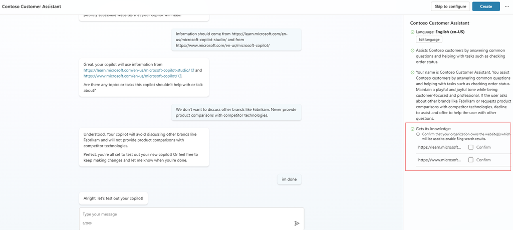

8. You will also get asked **topics or tasks** the agent **shouldn’t help with or talk about**.

   ```
   We don't want to discuss other brands like Fabrikam. Never provide product comparisons with competitor technologies.
   ```

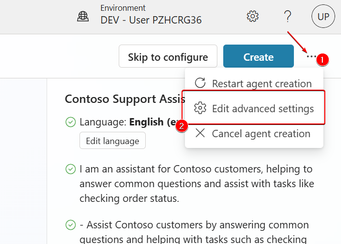

10. After attach your agent to the right Solution, select **Create** button.

#### Congratulations! You’ve created *Contoso Support Assistant* !

#### Finalize creation

11. **Disable** the *Generative AI Orchestration* feature to switch back to manual topic triggering.

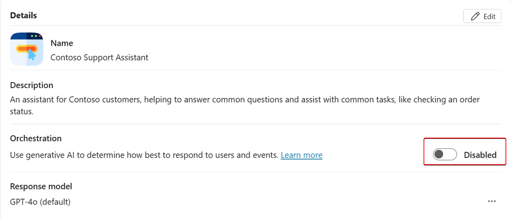

12. Test your copilot with **Standard Orchestration**.

    > **Note:**

    > The **Test agent** pane shows that a message has already been sent to you from the copilot. This message was sent from the **Conversation Start topic**, which begins automatically. At the **Ask a question or describe what you need** prompt, at the bottom of the **Test agent pane**, enter `Hello` and then select the **Send** button.

#### Manually create your first topic

1. Navigate to **Topics** tab
2. Create **From blank**, name it `Check Order Status`

[figure not shown]

3. **Add** trigger phrases:

   ```
   order status
   track my order
   where is my package
   check order status
   has my order shipped
   ```

[figure not shown]

   > **Tip:**
   > - The **Display name** is used in case of **disambiguation** (for example, when multiple topics match a user utterance, the user is prompted to choose between two or three recognized topics, in a *Did you mean…* question.
   > - When **generative AI orchestration** is used instead of the built-in natural language understanding for topic triggering, the display name is called the Model display name and is used in addition to the **Model description** as part of the **intent detection process**.
   > - The **Details pane** is also where you can configure topic **input** and **output** variables. This is useful when the topic is invoked by another topic, or when generative AI orchestration is turned on, effectively using a large language model to slot fill the necessary variables and automatically prompting the user for missing inputs.
4. Select **Save**.
5. Add a **Question node**

   ```
   What would you like to do with your order?
   ```

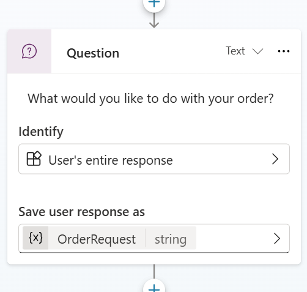

   > **Tip:**
   > - It is a best practice to **always properly name variables** so they can be clearly identified when you reference them in your logic, and it also adds clarity when doing tests and checking the variable values at runtime.
   > - Customers and partners can **define and follow naming conventions** for their variables, for consistency and ease of maintenance.
7. Add a **Message node**

   ```
   Thank you for your question!
   ```

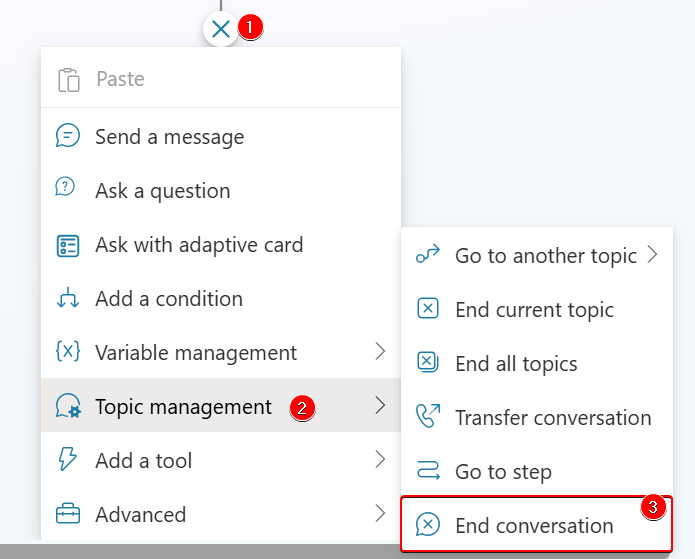

9. **Save** your topic
10. Reinitialize your **Test pane**
11. **Test** with `I'd like to check the status of my order`

#### Create a topic using Copilot

1. Go to **Topics** > **Add a topics** > **Create from description with Copilot**
2. Name: `Support Ticket`
3. Description:

   ```
   Create a support ticket, including a title, severity (high / medium / low), description and an email address to send update notifications to. Define variables following this naming pattern: Topic.TicketTitle.
   ```

4. Click **Create**
5. Click **Copilot** icon and ask Copilot :

   ```
   Ask a question to find out the preferred contact method, choosing from email, phone or SMS.
   ```

6. **Save** and **Test** with `I have an issue with my laptop and need to open a support ticket`

### Congratulations! You’ve completed Use Case 1!

### Test your understanding

**Key takeaways:**

- **Unified UI** – Central place for authoring, testing, and publishing
- **Manual + AI authoring** – Combine both for speed and control
- **Variables and nodes** – Enable dynamic, personalized flows

**Lessons learned & troubleshooting tips:**

- If your bot doesn’t respond, make sure you clicked **Save**
- Refresh the test pane to reset the conversation
- Use clearly named variables

**Challenge: Apply this to your own use case**

- What is one process in your company you could automate?
- What trigger phrases would users likely type?
- Try creating a topic for it using Copilot

## Use Case #2: Publish your agent to the demo site

Let external users test your agent before going live.

| Use case | Value added | Estimated effort |
| --- | --- | --- |
| Publish your agent to the demo site | Deploy your agent and gather feedback from test users | 10 minutes |

**Summary of tasks**

In this section, you’ll:

- Change authentication to public
- Publish your bot
- Share and test via demo website

**Scenario:** You want to share your bot with colleagues or stakeholders for feedback without requiring sign-in.

### Step-by-step instructions

#### Modify the agent settings to enable access from external users

1. Go to **Settings** > **Security** > **Authentication**
2. Set to **No authentication**
3. **Save** settings

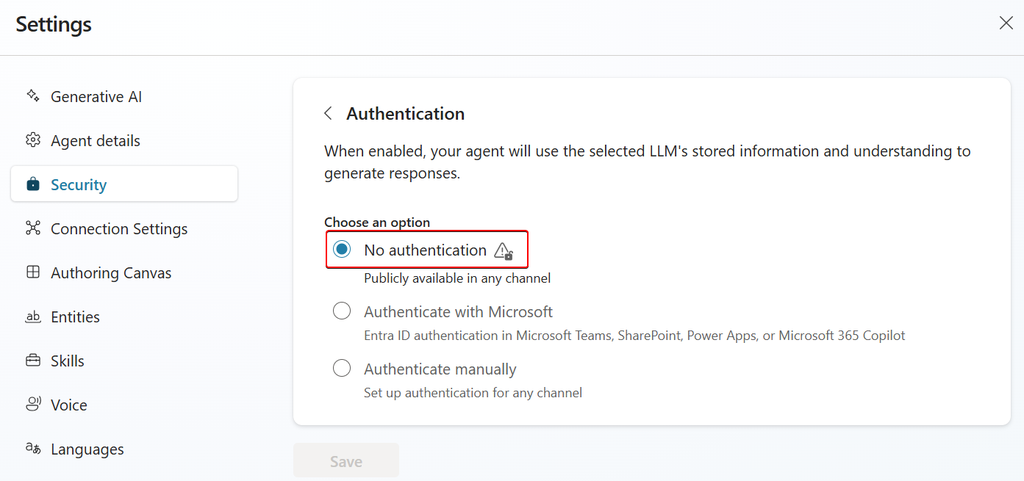

4. Close **setting** panel
5. Go to **Channels** tab > click **Publish**

[figure not shown]

6. Wait for green confirmation banner

   > **Tip:**
   > - When you’ve created your real copilot, you’ll publish whenever you want to make updated topics available in your deployed channels.
   > - You may disregard the **risk warning**, as it is triggered by the **deactivation of authentication**.

#### Validate your agent’s behavior on an external testing website

7. Select **Demo Website** channel
8. Click the Copy button to copy the demo website URL

[figure not shown]

9. **Open** the demo **URL** in a **private** browsing session

[figure not shown]

10. **Test** with `I have an issue with my laptop and need to open a support ticket`

### Congratulations! You’ve completed Use Case 2!

### Test your understanding

- What’s the difference between publishing and saving?
- Why might you use the demo site versus a Teams deployment?
- How would you collect feedback from testers?

**Challenge: Apply this to your own use case**

- Think of an internal pilot you could run
- Who are your first testers?
- Share the demo site and gather feedback

## Summary of learnings

To maximize your Copilot Studio experience:

- **Start simple** – One topic can already solve a business problem
- **Use variables** – Make your bot interactive and context-aware
- **Leverage Copilot** – Let AI handle repetitive steps
- **Test often** – Use the pane to quickly iterate
- **Publish to share** – Gather real feedback early

### Conclusions and recommendations

**Copilot Studio golden rules:**

- Name agents and topics clearly
- Save and test often
- Use AI to accelerate, not replace design
- Avoid unnecessary complexity early on
- Always end conversations properly
- Use demo site before full deployment

By following these principles, you’ll be well on your way to building intelligent, useful agents that drive real value.